# Lab 07 - Permutational Confidence Interval

Nonparametric statistics ay 2023/2024

2023/10/17

```r
seed = 2781991
B <- 1e3
```

## Permutational Confidence Intervals

Permutation testing (as the name suggests…) was not really born to make confidence intervals for given parameters, but of course, as shown in class, one can **compute exact confidence intervals** for given parameters by **performing test inversion** over a **grid of points** x.

It is relatively **computationally intensive**, thus we need a bit of “smart” code to do it. This lab would be indeed more complex from a computational point of view than a statistical one.

Let’s simulate some data…

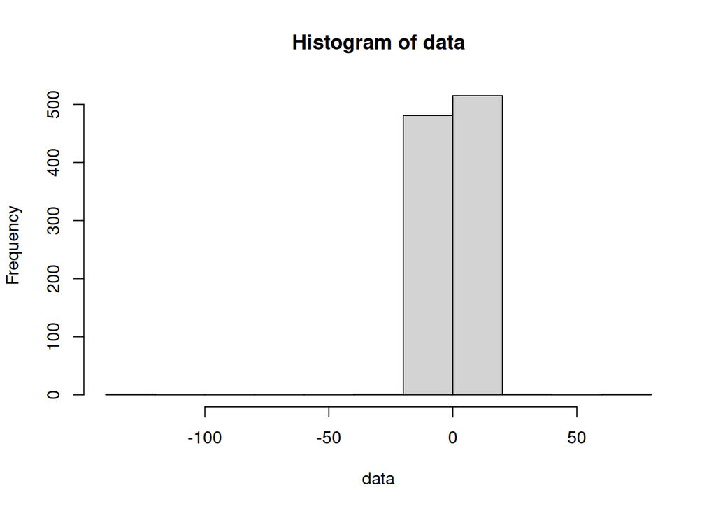

```r
set.seed(seed)
data=stabledist::rstable(1000,1.5,0)  # distribution with fat tails
hist(data)
```

Let’s calculate a confidence interval around the median of this distribution, that is…

```r
median(data)
```

```
## [1] 0.08800729
```

What we need to do is to test over a fine grid of alternative values that contain our true one the alternative hypothesis $H_1:med(X_1) \neq \mu_0$ where $X_1$ the R.V. representing the population I have a sample of.

To do so I use a **one population test on symmetric distributions for the mean**, where my permutation scheme is made of reflections of the data

```r
uni_t_perm <- function(data, mu0, B = 1000) {

  data_trans <- data - mu0
  T0 <- abs(median(data_trans))
  T_perm <- numeric(B)
  n <- length(data)

  for (perm in 1:B) {
    refl <- rbinom(n, 1, 0.5) * 2 - 1
    T_perm[perm] <- abs(median(data_trans * refl))
  }

  return(sum(T_perm >= T0)/B)
}
```

To have a reasonable spatial resolution we need to have a fine grid on which to perform our tests… which means that we need to run A LOT of tests. Observe that for each hypothesised mean (one element in the grid) we will have a test and its corresponding **probability of observing an equally or more extreme value for the test statistic with respect to the permutational distribution under $H_0$** (that is, the p-value). Hence, we will have a family of hypotheses testing each for a different mean:

$$H_{0,s}: MED(X_1) = \mu_s\;\; vs. \;\; H_{1,s}: MED(X_1) \neq \mu_s\; s
\in \mathcal{S}$$
where $\mathcal{S}$ represents the set of gridpoints:

```r
grid=seq(-3,3,by=0.001)
length(grid)
```

```
## [1] 6001
```

How to do it quickly on R? Vectorise operations instead of using for cycles. How to do it even faster? Parallelise such vectorised operations!

Let’s read the needed packages

```r
library(pbapply)
library(parallel)
```

Let’s create the cluster and initialize it. I need to start by understanding how many (logical…) cores my machine has. In my case I have…

```r
n_cores <- detectCores()
n_cores
```

```
## [1] 4
```

So, let’s create a cluster with `n_cores` cores!

```r
cl = makeCluster(n_cores)
```

I also need to “initialise” my cluster by sending information that are useful for the computation.

```r
clusterExport(cl,varlist=list("data","uni_t_perm"))
```

Now, I need to wrap up my function in a “wrapper” with the required arguments, and then start my parallel calculation!

```r
perm_wrapper <- function(grid_point) {
  uni_t_perm(data, grid_point, B = 2000)  # run a permutational t test where the hypothesised mean is the grid_point
}

pval_function <- pbsapply(grid, perm_wrapper, cl = cl)
```

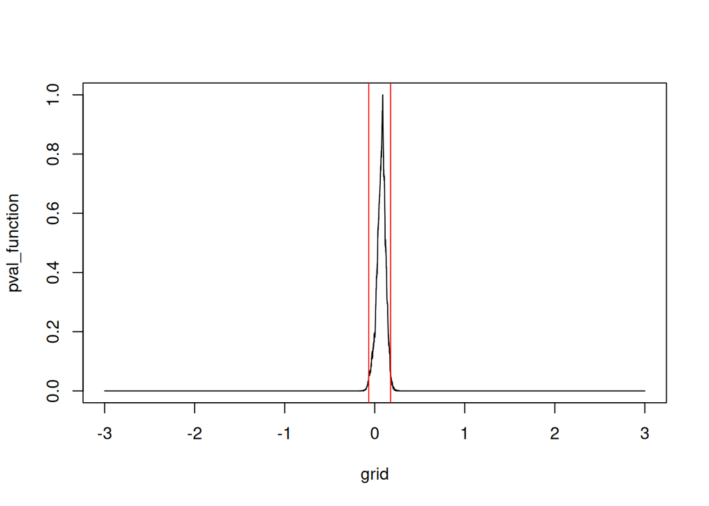

```r
alpha <- 0.05  # set the significance level
plot(grid, pval_function, type = "l")  # plot p-value function
values.within.CI <- grid[pval_function > alpha]
CI <- range(values.within.CI)  # obtain the confidence interval
abline(v=CI[1], col="red")
abline(v=CI[2], col="red")
```